# Project 2

Andrianina David Raharijao

2024-03-03

## Data sets

I will be looking at the following three data sets for this project:

- MTA Ridership (shared by Anna Moy)
- population data for 4 states (shared by Natalie Kalukeerthie)
- Language diversity (shared by me)

## MTA Ridership data:

#Tidying I first load the data from Github

```r
mta_df <- read_csv("https://raw.githubusercontent.com/Raharijao/Spring2024_Data_607_CUNYSPS/main/Week6/MTA_Daily_Ridership_Data__Beginning_2020_20240303.csv")
```

I delete some of the columns, as I will not need some of them for the analysis. I am left with the date and the total estimated ridership of the subway, buses, LIRR and Metro-North.

```r
#Get all the column names
print(colnames(mta_df))
```

```
##  [1] "Date"
##  [2] "Subways: Total Estimated Ridership"
##  [3] "Subways: % of Comparable Pre-Pandemic Day"
##  [4] "Buses: Total Estimated Ridership"
##  [5] "Buses: % of Comparable Pre-Pandemic Day"
##  [6] "LIRR: Total Estimated Ridership"
##  [7] "LIRR: % of Comparable Pre-Pandemic Day"
##  [8] "Metro-North: Total Estimated Ridership"
##  [9] "Metro-North: % of Comparable Pre-Pandemic Day"
## [10] "Access-A-Ride: Total Scheduled Trips"
## [11] "Access-A-Ride: % of Comparable Pre-Pandemic Day"
## [12] "Bridges and Tunnels: Total Traffic"
## [13] "Bridges and Tunnels: % of Comparable Pre-Pandemic Day"
## [14] "Staten Island Railway: Total Estimated Ridership"
## [15] "Staten Island Railway: % of Comparable Pre-Pandemic Day"
```

```r
mta_df_v1 <- mta_df[,c("Date",
                       "Subways: Total Estimated Ridership",
                       "Buses: Total Estimated Ridership",
                       "LIRR: Total Estimated Ridership",
                       "Metro-North: Total Estimated Ridership"
                       )]
```

```r
old_names <- c("Subways: Total Estimated Ridership",
               "Buses: Total Estimated Ridership",
               "LIRR: Total Estimated Ridership",
               "Metro-North: Total Estimated Ridership")

new_names <- c("Subway", "Bus", "LIRR", "Metro_North")
names(mta_df_v1)[names(mta_df_v1) %in% old_names] <- new_names
```

I turn the data from a wide format to a long format. I turned all of the columns exept for the Date

```r
mta_df_v1 <- pivot_longer(mta_df_v1,
                     cols = -c(Date),
                     names_to = "type",
                     values_to = "ridership")
```

Check for NA and delete with data conversion (for date, and for ridership)

```r
print(sum(is.na(mta_df_v1$ridership)))
```

```
## [1] 1
```

```r
mta_df_v1 <- mta_df_v1 %>%
  filter(!is.na(ridership))

mta_df_v1$Date <- as.Date(mta_df_v1$Date, format = "%m/%d/%Y")
mta_df_v1$year <- year(mta_df_v1$Date)
#Divide by 1000 to reduce the scale a bit
mta_df_v1$ridership <- (mta_df_v1$ridership)/1000
```

#Analysis

This graph displays the average ridership (by thousand people, this was done because the initial number’s scale was too big) of the different type of transportation by year. Overall, the subway and the bus enjoys the most ridership, LIRR and Metro North are significantly lower. However, while the average for the subway and buses have decreased between 2023 and 2024 (this might be due to the year just starting) the average ridership of LIRR and Metro North seems to be increasing as the year passes.

```r
mta_df_v2 <- mta_df_v1 %>%
  group_by(year,type) %>%
  summarize(mean_m = mean(ridership))
```

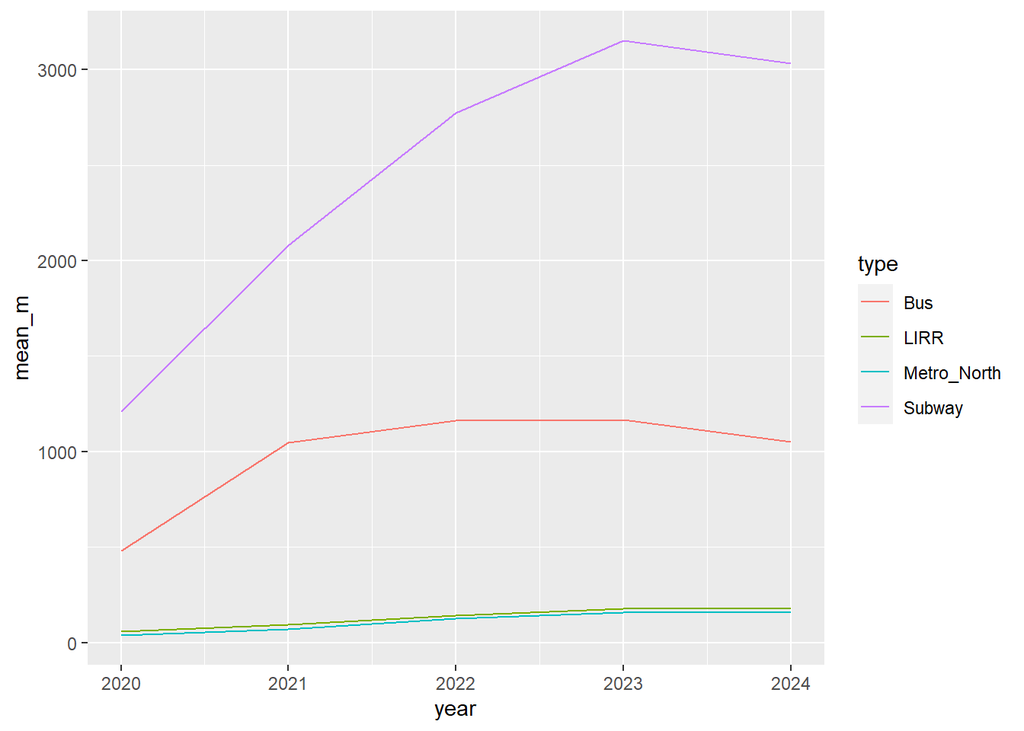

```r
ggplot(data = mta_df_v2, aes(x = year, y = mean_m, group = type, color = type)) +
  geom_line()
```

**Subway vs Buses in 2020**

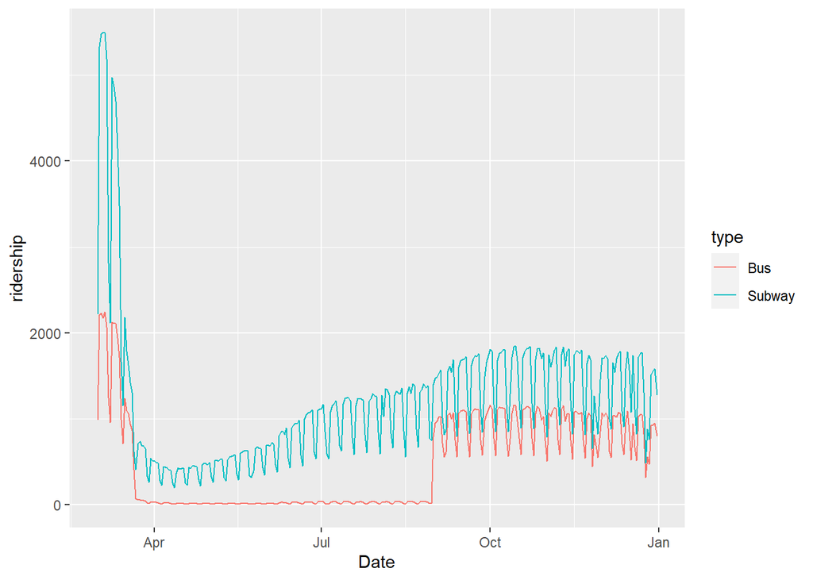

```r
mta_df_v3 <- mta_df_v1 %>%
  filter(type == "Subway" | type == "Bus", year == 2020)


ggplot(data = mta_df_v3, aes(x = Date, y = ridership, group = type, color = type)) +
  geom_line()
```

**Highest ridership in 2020**

```r
mta_df_v4 <- mta_df_v1 %>%
  filter(year == 2020)  %>%
  group_by(type) %>%
  summarize(total_ridership = sum(ridership)) %>%
  arrange(desc(total_ridership))

mta_df_v4
```

```
## # A tibble: 4 × 2
##   type        total_ridership
##   <chr>                 <dbl>
## 1 Subway              370097.
## 2 Bus                 147388.
## 3 LIRR                 17730.
## 4 Metro_North          11489.
```

##Language diversity

#Tidying Read the file

```r
lang_df <- read_csv("https://raw.githubusercontent.com/Raharijao/Spring2024_Data_607_CUNYSPS/main/Week6/language_diversity.csv")
```

Turn the data into wide format:

```r
lang_df_1 <- lang_df %>%
  pivot_wider(names_from = Measurement, values_from = Value)
```

#Analysis

```r
lang_df_2 <- lang_df_1 %>%
  group_by(Continent) %>%
  summarize(sum_l = sum(Langs))

#ggplot(data = lang_df_2, aes(x = Continent, y = sum_l)) +
  #geom_bar()
```

##Population data for 4 states

#Tidying

```r
pop_df <- read_csv("https://raw.githubusercontent.com/nk014914/Data-607/main/Population_data.csv")
```

Renamed Columns:

```r
old_names <- c("2015 Population",
               "2016 Population",
               "2017 Population",
               "2018 Population",
               "2019 Population",
               "2020 Population")

new_names <- c("2015", "2016", "2017", "2018","2019","2020")
names(pop_df)[names(pop_df) %in% old_names] <- new_names
```

Filtered out blank rows, and turned the table into long format

```r
pop_df <- pop_df %>%
  filter(!is.na(Name))

pop_df_1 <- pivot_longer(pop_df,
                     cols = -c(Name,FIPS,Abbreviations),
                     names_to = "year",
                     values_to = "count")
```